# Chan-Presentation

5/14/2021

## Gas Vehicle Fuel Efficency

## Dataset

- Data is from United States Department of Energy and the Environmental Protection Agency
- The dataset contains all the car manufactures makes and models that are sold in the US
- This dataset is constantly being updated with new makes and models and contains over 43,000 different types of makes and models from 1984 to 2021.
- The dataset includes a data dictionary that can be found on the [United States of Energy Fuel Economy](https://www.fueleconomy.gov/feg/ws/index.shtml#vehicle)
- In the dataset we will be strictly looking at only gas engine cars and will be filtering out hybrids, diesel, and electric cars.

## Question

Has fuel economy peaked throughout the years.

- Increase fuel economy regulations from the EPA and government
- Improvement in gas engine technology
- Improvement to aero dynamics of vehicles.

## Looking at the data

Can see a positive trend and see that the minimum MPG has been increasing throughout the years, but has MPG peaked ?

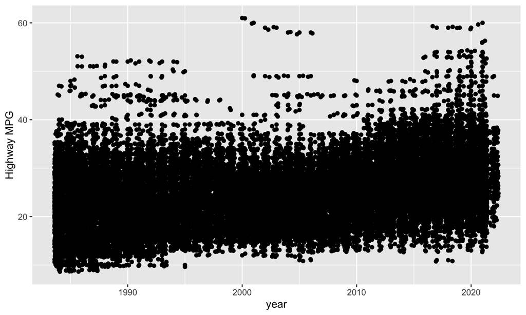

## Loess Regression

- Loess Regression is a smoothing technique which uses the local weights of each value in order to create a regression line
- The Loess Regression relies on different span sizes in order to get different levels of smoothing

[figure not shown]

## Loess Regression Highway Fuel Economy

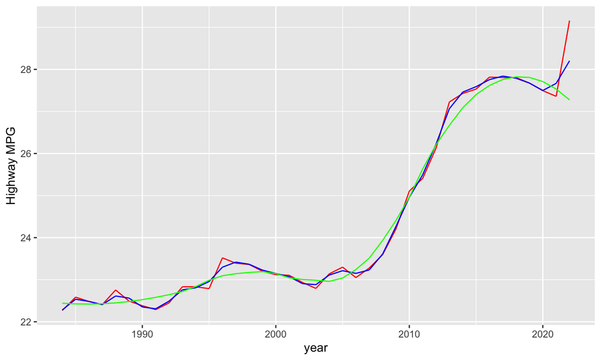

## Loess Regression City Fuel Economy

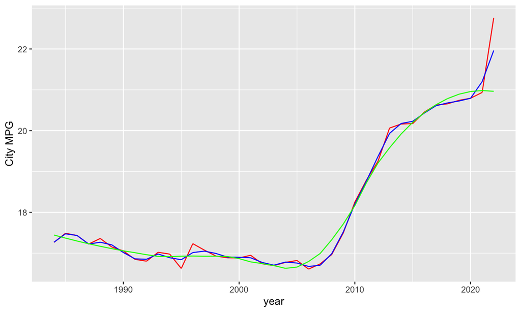

## Loess Regression Fuel Economy

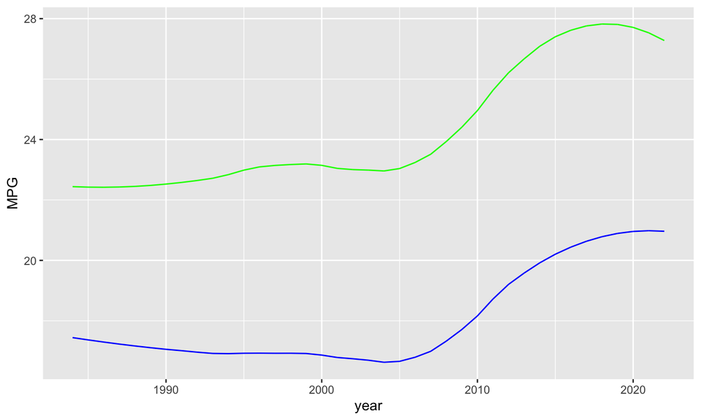

## GGPairs

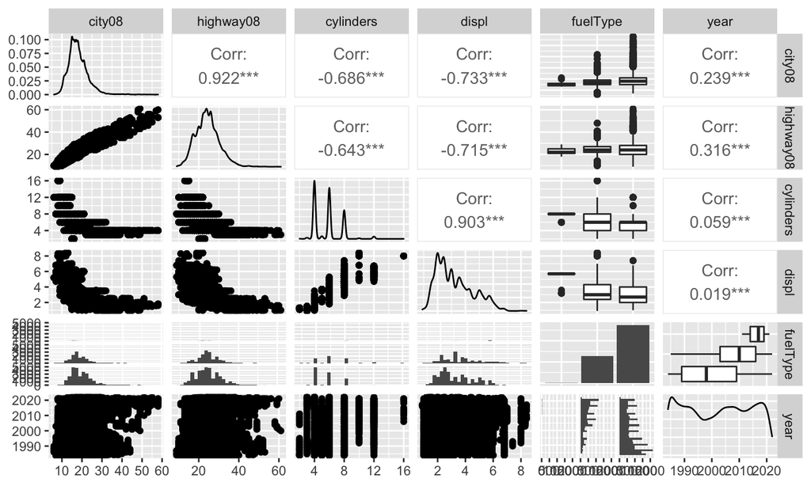

## Linar Regression: City Fuel Economy

```
##
## Call:
## lm(formula = city08 ~ cylinders + displ, data = dataset)
##
## Residuals:
##     Min      1Q  Median      3Q     Max
## -10.043  -1.910  -0.446   1.394  36.028
##
## Coefficients:
##             Estimate Std. Error t value Pr(>|t|)
## (Intercept) 27.63155    0.05962  463.45   <2e-16 ***
## cylinders   -0.37033    0.02235  -16.57   <2e-16 ***
## displ       -2.32128    0.02976  -78.00   <2e-16 ***
## ---
## Signif. codes:  0 '***' 0.001 '**' 0.01 '*' 0.05 '.' 0.1 ' ' 1
##
## Residual standard error: 3.374 on 40249 degrees of freedom
##   (3 observations deleted due to missingness)
## Multiple R-squared:  0.5403, Adjusted R-squared:  0.5402
## F-statistic: 2.365e+04 on 2 and 40249 DF,  p-value: < 2.2e-16
```

## Linear Regression: City Fuel Economy

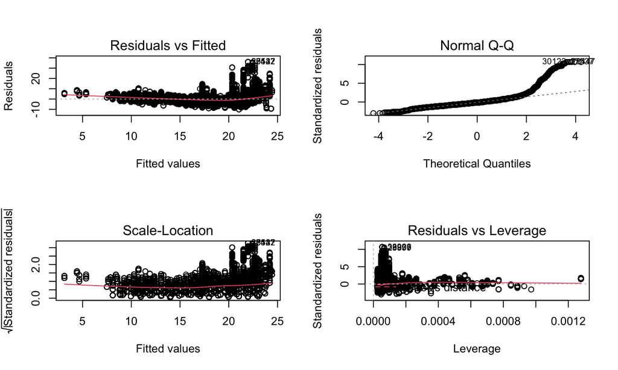

## Linear Regression: Highway Fuel Economy

```
##
## Call:
## lm(formula = highway08 ~ cylinders + displ, data = dataset)
##
## Residuals:
##      Min       1Q   Median       3Q      Max
## -15.0384  -2.6873  -0.2566   2.4722  30.5255
##
## Coefficients:
##             Estimate Std. Error t value Pr(>|t|)
## (Intercept) 34.45326    0.07236  476.17   <2e-16 ***
## cylinders    0.05315    0.02712    1.96     0.05 .
## displ       -3.24459    0.03612  -89.83   <2e-16 ***
## ---
## Signif. codes:  0 '***' 0.001 '**' 0.01 '*' 0.05 '.' 0.1 ' ' 1
##
## Residual standard error: 4.094 on 40249 degrees of freedom
##   (3 observations deleted due to missingness)
## Multiple R-squared:  0.5118, Adjusted R-squared:  0.5118
## F-statistic: 2.11e+04 on 2 and 40249 DF,  p-value: < 2.2e-16
```

## Linear Regression: Highway Fuel Economy

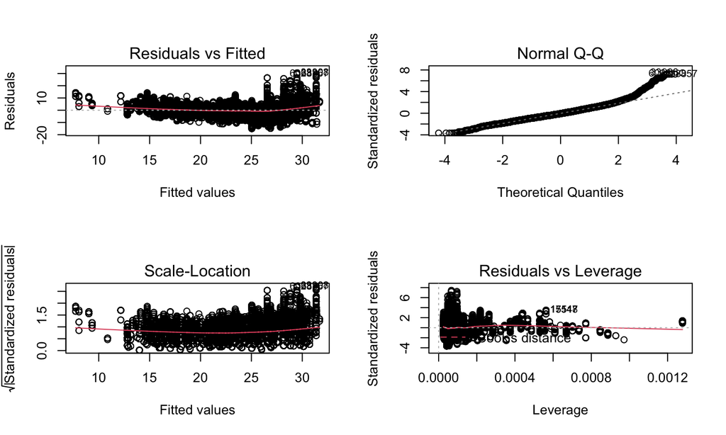

## Conclusion

- Fuel economy is affected by the economy which also effects gas prices and consumer spending
- Fuel economy ias indeed plateaued in recent years due to consumers buying more SUVs
  - Auto manufactures like Ford and General Motors are no longer making any more sedans
- Would like to see how COVID and the recession will impact the fuel economy